# Medidas de tendencia central

[Becerril sanchez jose luis](https://Luisbecerril24.github.io)

Estadística 2022-2, [Facultad de economía](http://www.economia.unam.mx/)

2/3/2022

### 1. ¿Qué son las medidas de tendencia central? 🤔

> **“Las medidas de tendencia central son parámetros estadísticos que informan sobre el centro de la distribución de la [muestra](https://economipedia.com/definiciones/muestra-estadistica.html)o [población estadística](https://economipedia.com/definiciones/poblacion-estadistica.html)”**

[Economipedia (2022)](https://economipedia.com/definiciones/medidas-de-tendencia-central.html)

Para este ejemplo, primero generaremos una serie de **100** números aleatorios entre **1** y **20** mediante la función `sample`. El argumento `TRUE` nos permitirá generar una muestra con remplazo:

```r
numeros <- sample(1:20, 100, TRUE)
numeros
```

```
##   [1] 18 14 15  7  3 14  7  1  7  9 16  7 15 13  4 10 20 18  8 18  8  9 16 17  5
##  [26] 11 15  4 18 17 19 11 19 14 11 12  9 14  2 11 19  8  1  9  7  5  1 10  3  7
##  [51]  8  2 17 20 18  4  6 19 20 16  4  3 16  8  7 11  4 20 13 16  5 16  6  3  2
##  [76]  1  8 19  5 10  5  4 19 14  5 10  4 11 10 10  8 11 10  4  9 19  5 19 11 13
```

### 2. Mediana 📍

> “La [**mediana**](https://economipedia.com/definiciones/mediana.html)es un [**estadístico**](https://economipedia.com/definiciones/estadistico.html) de posición central que parte la distribución en dos, es decir, deja la misma cantidad de valores a un lado que a otro”

[Economipedia (2022)](https://economipedia.com/definiciones/medidas-de-tendencia-central.html)

Para obtener la **mediana**, podemos ordenar los `numeros` de menor a mayor, **el número que esté en medio de la muestra será la mediana**. Si utilizamos R, se puede hacer el cálculo de la **mediana** con la función `median`:

```r
mediana <- median(numeros)
mediana
```

```
## [1] 10
```

### 3. Media 🧮

> “La [**media**](https://economipedia.com/definiciones/media.html)es el valor promedio de un conjunto de datos numéricos, calculada como la suma del conjunto de valores dividida entre el número total de valores”

[Economipedia (2022)](https://economipedia.com/definiciones/medidas-de-tendencia-central.html)

$$Media ={\frac {1}{n}}\sum _{i=1}^{n}a_{i}={\frac {a_{1}+a_{2}+\cdots +a_{n}}{n}}$$

Si usamos R, podemos obtener la media de una muestra si utlilizamos la función **mean**:

```r
media <- mean(numeros)
media
```

```
## [1] 10.44
```

### 4. Moda 📊

> “La moda es el valor que más se repite en una muestra estadística o población. No tiene fórmula en sí mismo. Lo que habría que realizar es la suma de las repeticiones de cada valor”

[Economipedia (2022)](https://economipedia.com/definiciones/medidas-de-tendencia-central.html)

Podemos saber cuál es la **frecuencia** (número de veces que aparece un elemento en una muestra) de cada número si dibujamos un **histograma** con la función `hist`, **aquel elemento con mayor frecuencia será la moda**:

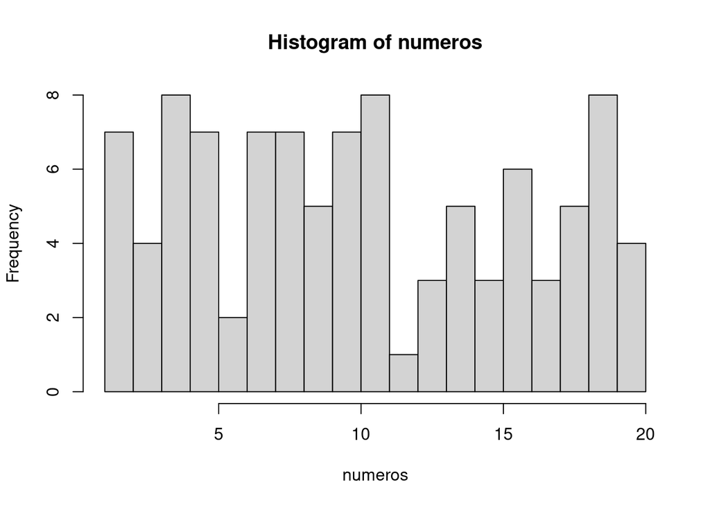

```r
# El argumento breaks nos permite dividir en histograma en las partes que queramos
hist(numeros, breaks = 20)
```

Para obtener un resultado con más precisión, podemos obtener la **moda** si generamos una **tabla de frecuencias** con la función `table` y la función `data.frame`, **aquel elemento con mayor frecuencia será la moda**:

```r
tabla.frecuencias <- data.frame(table(numeros))
tabla.frecuencias
```

```
##    numeros Freq
## 1        1    4
## 2        2    3
## 3        3    4
## 4        4    8
## 5        5    7
## 6        6    2
## 7        7    7
## 8        8    7
## 9        9    5
## 10      10    7
## 11      11    8
## 12      12    1
## 13      13    3
## 14      14    5
## 15      15    3
## 16      16    6
## 17      17    3
## 18      18    5
## 19      19    8
## 20      20    4
```

### 5. Ejercicio 👩‍💻👨‍💻✍

Aplica lo que aprendiste, obten la **mediana**, **media** y **moda** de la siguiente muestra de números:

```r
# Con la función seq, creamos una secuencia de 1 a 10 en intervalos de 0.1 en 0.1
secuencia <- seq(1, 10, 0.1)
muestra <- sample(secuencia, 100, TRUE)
muestra
```

```
##   [1]  7.7  1.8  9.7  6.2  2.9  2.3  4.7  1.3  3.7 10.0  5.2 10.0  5.4  8.2  5.5
##  [16]  6.3  2.9  4.2  3.3  2.1  2.9  3.8  8.6  7.2  9.2  3.2  4.8  5.9  5.9  9.7
##  [31]  8.5  4.5  5.5  5.8  1.3  5.1  6.7  6.3  3.6  4.3  3.5  3.6  6.8  3.9  4.3
##  [46]  9.9  3.7  9.3  9.3  6.6  6.3  5.1  3.6  1.8  3.4  5.8  5.6  4.5  4.3  2.9
##  [61]  3.6  3.2  8.3  4.3  2.4  8.9  4.3  7.2  4.2  8.8  1.8  4.0  4.8  6.8  1.7
##  [76]  5.6  9.8  2.1  1.7  4.0  7.9  8.9  1.4  7.7  7.5  2.2  1.2  8.4  7.3  9.9
##  [91]  5.9  9.8  5.0  6.3  9.0  7.5  6.4  1.8  4.8  9.4
```

##### Mediana

```r
mediana.muestra <- median (muestra)
mediana.muestra
```

```
## [1] 5.15
```

##### Media

```r
media.muestra <- mean(muestra)
media.muestra
```

```
## [1] 5.462
```

##### Moda

```r
tabla.muestra <- data.frame(table(muestra))
tabla.muestra
```

```
##    muestra Freq
## 1      1.2    1
## 2      1.3    2
## 3      1.4    1
## 4      1.7    2
## 5      1.8    4
## 6      2.1    2
## 7      2.2    1
## 8      2.3    1
## 9      2.4    1
## 10     2.9    4
## 11     3.2    2
## 12     3.3    1
## 13     3.4    1
## 14     3.5    1
```

[output cut: 44 more lines]

💻[Código disponible en RStudio Cloud](https://rstudio.cloud/project/3671022)💻